# A5_Tessmann_Meag

Meag Tessmann

3/9/2020

# Data Source

1. Social media data: snsbinary.csv (a slightly different file from Week 8 tutorial)

Note that this dataset is slightly different from the Week 8 tutorial, in that this dataset also has information about each teen’s graduation year, gender, age, and the number of friends on the social networking service.

2. Walmart and Kaggle: Walmart_basket.csv

Walmart held its 3rd Kaggle “recruiting” competition (https://www.kaggle.com/c/walmart-recruiting-trip- type-classification) in Fall 2015 to attract data scientists who are interested in getting a job at Walmart.

Our data file, Walmart_basket.csv, was derived from the original Kaggle data for market basket analysis and is in a “long format.” The variable “VisitNumber” is the transaction id and the variable “DepartmentDescription” provides high-level description of the items purchased.

# K-mean Clustering

K-means clustering (use snsbinary.csv)

A. Load packages and import snsbinary.csv using the “read.csv()” function with “stringsAsFactors = TRUE”. Assign the data to a data frame called “teensbinary”. Show the structure of the data.

B. Change the variable “gradyear” to a factor variable and show the summary of the data.

C. Run the following code to clean the dataset and remove outliers or missing datapoints.

D. Run SimpleKMeans to create 5 clusters using the Euclidean distance. Show the model including the standard deviations of each cluster.

E. Run SimpleKMeans to create 5 clusters using the Euclidean distance and Kmeans++. Show the model including the standard deviations of each cluster.

```r
knitr::opts_chunk$set(echo = TRUE)


#############
##### A #####
#############

library(RWeka)
library(arules)
library(skimr)
library(knitr)
library(tidyverse)
teensbinary <- read.csv('snsbinary.csv', stringsAsFactors = TRUE)
skim(teensbinary)
```

```
## Skim summary statistics
##  n obs: 22441
##  n variables: 40
##
## ── Variable type:factor ─────────────────────────────────────────────────────────────────────────
##  variable missing complete     n n_unique               top_counts ordered
##    gender       0    22441 22441        2 F: 18240, M: 4201, NA: 0   FALSE
##
## ── Variable type:integer ────────────────────────────────────────────────────────────────────────
##      variable missing complete     n     mean    sd   p0  p25  p50  p75 p100
##   abercrombie       0    22441 22441    0.045  0.21    0    0    0    0    1
##          band       0    22441 22441    0.16   0.37    0    0    0    0    1
##      baseball       0    22441 22441    0.074  0.26    0    0    0    0    1
##    basketball       0    22441 22441    0.18   0.38    0    0    0    0    1
##         bible       0    22441 22441    0.017  0.13    0    0    0    0    1
##        blonde       0    22441 22441    0.064  0.25    0    0    0    0    1
##  cheerleading       0    22441 22441    0.066  0.25    0    0    0    0    1
##        church       0    22441 22441    0.16   0.36    0    0    0    0    1
##       clothes       0    22441 22441    0.12   0.33    0    0    0    0    1
##          cute       0    22441 22441    0.23   0.42    0    0    0    0    1
##         dance       0    22441 22441    0.24   0.43    0    0    0    0    1
##         death       0    22441 22441    0.1    0.3     0    0    0    0    1
##           die       0    22441 22441    0.14   0.35    0    0    0    0    1
##         dress       0    22441 22441    0.088  0.28    0    0    0    0    1
##         drugs       0    22441 22441    0.049  0.21    0    0    0    0    1
##         drunk       0    22441 22441    0.071  0.26    0    0    0    0    1
##      football       0    22441 22441    0.19   0.39    0    0    0    0    1
##       friends       0    22441 22441   31.46  36.61    0    5   21   45  830
##           god       0    22441 22441    0.29   0.45    0    0    0    1    1
##      gradyear       0    22441 22441 2007.5    1.11 2006 2007 2007 2008 2009
##          hair       0    22441 22441    0.25   0.43    0    0    0    0    1
##     hollister       0    22441 22441    0.056  0.23    0    0    0    0    1
##           hot       0    22441 22441    0.099  0.3     0    0    0    0    1
##         jesus       0    22441 22441    0.08   0.27    0    0    0    0    1
##        kissed       0    22441 22441    0.07   0.25    0    0    0    0    1
##          mall       0    22441 22441    0.19   0.39    0    0    0    0    1
##      marching       0    22441 22441    0.032  0.18    0    0    0    0    1
##         music       0    22441 22441    0.49   0.5     0    0    0    1    1
##          rock       0    22441 22441    0.18   0.39    0    0    0    0    1
##           sex       0    22441 22441    0.12   0.32    0    0    0    0    1
```

[output cut: 38 more lines]

```
##  ▇▁▁▁▁▁▁▁
##  ▇▁▁▁▁▁▁▁
##  ▇▁▁▁▁▁▁▃
##  ▇▁▁▁▁▁▁▁
##  ▇▁▁▁▁▁▁▁
##  ▇▁▁▁▁▁▁▁
##  ▇▁▁▁▁▁▁▁
##  ▇▁▁▁▁▁▁▁
##  ▇▁▁▁▁▁▁▁
##
## ── Variable type:numeric ────────────────────────────────────────────────────────────────────────
##  variable missing complete     n  mean   sd   p0  p25   p50   p75   p100
##       age       0    22441 22441 17.92 7.53 3.63 16.3 17.27 18.24 106.93
##      hist
##  ▃▇▁▁▁▁▁▁
```

```r
#############
##### B #####
#############

teensbinary <- teensbinary %>%
  mutate(gradyear=factor(gradyear))

summary(teensbinary)
```

```
##  gradyear    gender         age            friends         basketball
##  2006:5600   F:18240   Min.   :  3.63   Min.   :  0.00   Min.   :0.0000
##  2007:5649   M: 4201   1st Qu.: 16.30   1st Qu.:  5.00   1st Qu.:0.0000
##  2008:5654             Median : 17.27   Median : 21.00   Median :0.0000
##  2009:5538             Mean   : 17.92   Mean   : 31.46   Mean   :0.1786
##                        3rd Qu.: 18.24   3rd Qu.: 45.00   3rd Qu.:0.0000
##                        Max.   :106.93   Max.   :830.00   Max.   :1.0000
##     football          soccer          softball         volleyball
##  Min.   :0.0000   Min.   :0.0000   Min.   :0.00000   Min.   :0.00000
##  1st Qu.:0.0000   1st Qu.:0.0000   1st Qu.:0.00000   1st Qu.:0.00000
##  Median :0.0000   Median :0.0000   Median :0.00000   Median :0.00000
##  Mean   :0.1864   Mean   :0.1135   Mean   :0.08935   Mean   :0.08667
##  3rd Qu.:0.0000   3rd Qu.:0.0000   3rd Qu.:0.00000   3rd Qu.:0.00000
##  Max.   :1.0000   Max.   :1.0000   Max.   :1.00000   Max.   :1.00000
##     swimming       cheerleading        baseball           tennis
##  Min.   :0.0000   Min.   :0.00000   Min.   :0.00000   Min.   :0.00000
##  1st Qu.:0.0000   1st Qu.:0.00000   1st Qu.:0.00000   1st Qu.:0.00000
##  Median :0.0000   Median :0.00000   Median :0.00000   Median :0.00000
##  Mean   :0.1095   Mean   :0.06626   Mean   :0.07411   Mean   :0.05325
##  3rd Qu.:0.0000   3rd Qu.:0.00000   3rd Qu.:0.00000   3rd Qu.:0.00000
##  Max.   :1.0000   Max.   :1.00000   Max.   :1.00000   Max.   :1.00000
##      sports            cute             sex              sexy
##  Min.   :0.0000   Min.   :0.0000   Min.   :0.0000   Min.   :0.0000
##  1st Qu.:0.0000   1st Qu.:0.0000   1st Qu.:0.0000   1st Qu.:0.0000
##  Median :0.0000   Median :0.0000   Median :0.0000   Median :0.0000
##  Mean   :0.1241   Mean   :0.2259   Mean   :0.1172   Mean   :0.1116
##  3rd Qu.:0.0000   3rd Qu.:0.0000   3rd Qu.:0.0000   3rd Qu.:0.0000
##  Max.   :1.0000   Max.   :1.0000   Max.   :1.0000   Max.   :1.0000
##       hot             kissed            dance             band
##  Min.   :0.0000   Min.   :0.00000   Min.   :0.0000   Min.   :0.0000
##  1st Qu.:0.0000   1st Qu.:0.00000   1st Qu.:0.0000   1st Qu.:0.0000
##  Median :0.0000   Median :0.00000   Median :0.0000   Median :0.0000
##  Mean   :0.0991   Mean   :0.06974   Mean   :0.2385   Mean   :0.1629
##  3rd Qu.:0.0000   3rd Qu.:0.00000   3rd Qu.:0.0000   3rd Qu.:0.0000
##  Max.   :1.0000   Max.   :1.00000   Max.   :1.0000   Max.   :1.0000
##     marching           music             rock            god
##  Min.   :0.00000   Min.   :0.0000   Min.   :0.000   Min.   :0.0000
##  1st Qu.:0.00000   1st Qu.:0.0000   1st Qu.:0.000   1st Qu.:0.0000
##  Median :0.00000   Median :0.0000   Median :0.000   Median :0.0000
##  Mean   :0.03195   Mean   :0.4938   Mean   :0.184   Mean   :0.2884
```

[output cut: 15 more lines]

```
##  Max.   :1.00000   Max.   :1.00000   Max.   :1.0000   Max.   :1.0000
##     clothes        hollister        abercrombie           die
##  Min.   :0.000   Min.   :0.00000   Min.   :0.00000   Min.   :0.0000
##  1st Qu.:0.000   1st Qu.:0.00000   1st Qu.:0.00000   1st Qu.:0.0000
##  Median :0.000   Median :0.00000   Median :0.00000   Median :0.0000
##  Mean   :0.125   Mean   :0.05601   Mean   :0.04545   Mean   :0.1428
##  3rd Qu.:0.000   3rd Qu.:0.00000   3rd Qu.:0.00000   3rd Qu.:0.0000
##  Max.   :1.000   Max.   :1.00000   Max.   :1.00000   Max.   :1.0000
##      death             drunk             drugs
##  Min.   :0.00000   Min.   :0.00000   Min.   :0.00000
##  1st Qu.:0.00000   1st Qu.:0.00000   1st Qu.:0.00000
##  Median :0.00000   Median :0.00000   Median :0.00000
##  Mean   :0.09973   Mean   :0.07143   Mean   :0.04853
##  3rd Qu.:0.00000   3rd Qu.:0.00000   3rd Qu.:0.00000
##  Max.   :1.00000   Max.   :1.00000   Max.   :1.00000
```

```r
#############
##### C #####
#############

teensbinary$age <- ifelse(teensbinary$age >= 13 & teensbinary$age < 20, teensbinary$age, NA)
teens_cleaned <- subset(teensbinary,!(is.na(teensbinary["gender"]) | is.na(teensbinary["age"])))
teens_cleaned <- teens_cleaned[which(teens_cleaned$friends <= 400),]


#############
##### D #####
#############

teen_default <- SimpleKMeans(teens_cleaned, Weka_control(N=5, V=TRUE))
teen_default
```

```
##
## kMeans
## ======
##
## Number of iterations: 17
## Within cluster sum of squared errors: 86895.90590281351
##
## Initial starting points (random):
##
## Cluster 0: 2008,F,16.578,29,0,0,0,0,0,0,0,0,0,0,0,0,0,0,0,0,0,0,1,0,1,0,0,0,0,0,0,0,0,0,0,0,0,0,0,0
## Cluster 1: 2007,F,17.177,35,0,0,0,0,0,0,0,0,0,0,1,0,0,0,0,0,0,0,0,0,0,0,0,0,1,1,0,0,1,0,0,0,0,0,0,0
## Cluster 2: 2006,F,19.179,11,0,1,0,0,0,0,0,0,0,1,0,0,0,0,0,1,0,0,1,0,0,0,0,0,0,0,0,1,1,0,0,0,0,0,0,0
## Cluster 3: 2008,F,17.136,107,0,0,1,0,0,0,0,0,0,0,0,0,1,0,0,0,0,0,1,0,0,0,0,0,1,0,0,0,1,0,0,0,0,0,0,0
## Cluster 4: 2008,F,16.627,69,0,0,0,1,1,0,0,1,0,0,0,0,0,0,0,0,0,0,0,0,1,0,0,0,0,0,0,1,1,0,0,0,0,0,0,0
##
## Missing values globally replaced with mean/mode
##
## Final cluster centroids:
##                               Cluster#
## Attribute        Full Data           0           1           2           3           4
##                  (22089.0)    (5043.0)    (5160.0)    (5197.0)    (2307.0)    (4382.0)
## ======================================================================================
## gradyear              2007        2008        2007        2006        2009        2009
##   2006         5511.0 ( 24%)  0.0 (  0%)  0.0 (  0%)5197.0 (100%)314.0 ( 13%)  0.0 (  0%)
##   2007         5573.0 ( 25%)  0.0 (  0%)5160.0 (100%)  0.0 (  0%)413.0 ( 17%)  0.0 (  0%)
##   2008         5562.0 ( 25%)5043.0 (100%)  0.0 (  0%)  0.0 (  0%)519.0 ( 22%)  0.0 (  0%)
##   2009         5443.0 ( 24%)  0.0 (  0%)  0.0 (  0%)  0.0 (  0%)1061.0 ( 45%)4382.0 (100%)
##
## gender                   F           F           F           F           F           F
##   F            17977.0 ( 81%)4130.0 ( 81%)4113.0 ( 79%)4009.0 ( 77%)2171.0 ( 94%)3554.0 ( 81%)
##   M            4112.0 ( 18%)913.0 ( 18%)1047.0 ( 20%)1188.0 ( 22%)136.0 (  5%)828.0 ( 18%)
##
## age                17.2439     16.7697     17.7089     18.6643     16.7334     15.8265
##                  +/-1.1525   +/-0.4324   +/-0.4437   +/-0.5191   +/-1.1085   +/-0.4789
##
## friends            31.3909     31.2907     31.6434     27.1224     39.1179     32.2031
##                 +/-35.4435  +/-35.3125  +/-35.6917  +/-31.1827  +/-41.4817   +/-35.856
##
## basketball          0.1793      0.1666      0.1483       0.133      0.3684       0.186
##                  +/-0.3836   +/-0.3726   +/-0.3554   +/-0.3396   +/-0.4825   +/-0.3891
```

[output cut: 90 more lines]

```
##
## abercrombie         0.0456      0.0405      0.0312      0.0241      0.1469      0.0408
##                  +/-0.2087    +/-0.197   +/-0.1739   +/-0.1532   +/-0.3541    +/-0.198
##
## die                 0.1425      0.1162      0.1223      0.1093      0.4018      0.0995
##                  +/-0.3496   +/-0.3205   +/-0.3276    +/-0.312   +/-0.4904   +/-0.2994
##
## death               0.0999      0.0869      0.0864      0.0877      0.2315       0.076
##                  +/-0.2999   +/-0.2816    +/-0.281   +/-0.2829   +/-0.4219    +/-0.265
##
## drunk               0.0715      0.0488      0.0564      0.0662      0.2284       0.039
##                  +/-0.2576   +/-0.2154   +/-0.2307   +/-0.2486   +/-0.4199   +/-0.1937
##
## drugs               0.0484      0.0307      0.0283      0.0289      0.2323      0.0189
##                  +/-0.2147   +/-0.1726   +/-0.1658   +/-0.1674   +/-0.4224   +/-0.1363
```

```r
#############
##### E #####
#############

teen_k_plus <- SimpleKMeans(teens_cleaned, Weka_control(N=5, V=TRUE, init=1))
teen_k_plus
```

```
##
## kMeans
## ======
##
## Number of iterations: 18
## Within cluster sum of squared errors: 86890.90914266332
##
## Initial starting points (k-means++):
##
## Cluster 0: 2008,F,16.578,29,0,0,0,0,0,0,0,0,0,0,0,0,0,0,0,0,0,0,1,0,1,0,0,0,0,0,0,0,0,0,0,0,0,0,0,0
## Cluster 1: 2007,F,18.272,0,0,0,0,0,0,0,1,0,0,0,0,0,0,0,0,0,1,0,0,0,0,0,0,0,0,0,0,0,0,0,0,0,0,0,0,0
## Cluster 2: 2008,F,16.496,13,0,0,0,0,0,0,0,0,1,0,0,0,0,0,0,1,1,0,0,0,0,0,0,0,0,0,1,0,0,0,0,0,0,0,0,0
## Cluster 3: 2006,F,18.856,34,0,1,0,0,0,0,0,0,0,0,0,0,0,0,0,0,0,0,1,0,1,0,1,0,0,0,1,0,1,0,0,0,0,0,0,0
## Cluster 4: 2006,F,18.563,23,0,0,0,0,0,0,0,0,0,0,1,1,0,0,1,1,1,0,1,1,1,0,0,0,1,0,1,0,0,1,0,0,1,1,0,0
##
## Missing values globally replaced with mean/mode
##
## Final cluster centroids:
##                               Cluster#
## Attribute        Full Data           0           1           2           3           4
##                  (22089.0)    (4556.0)    (5166.0)    (4951.0)    (5197.0)    (2219.0)
## ======================================================================================
## gradyear              2007        2008        2007        2009        2006        2008
##   2006         5511.0 ( 24%)  0.0 (  0%)  0.0 (  0%)  0.0 (  0%)5197.0 (100%)314.0 ( 14%)
##   2007         5573.0 ( 25%)  0.0 (  0%)5166.0 (100%)  0.0 (  0%)  0.0 (  0%)407.0 ( 18%)
##   2008         5562.0 ( 25%)4556.0 (100%)  0.0 (  0%)  0.0 (  0%)  0.0 (  0%)1006.0 ( 45%)
##   2009         5443.0 ( 24%)  0.0 (  0%)  0.0 (  0%)4951.0 (100%)  0.0 (  0%)492.0 ( 22%)
##
## gender                   F           F           F           F           F           F
##   F            17977.0 ( 81%)3686.0 ( 80%)4119.0 ( 79%)4089.0 ( 82%)4011.0 ( 77%)2072.0 ( 93%)
##   M            4112.0 ( 18%)870.0 ( 19%)1047.0 ( 20%)862.0 ( 17%)1186.0 ( 22%)147.0 (  6%)
##
## age                17.2439     16.7699     17.7084     15.8253     18.6634     16.9767
##                  +/-1.1525    +/-0.434   +/-0.4438   +/-0.4757   +/-0.5219   +/-0.9947
##
## friends            31.3909      30.545     31.7191     33.6379     27.1328     37.3227
##                 +/-35.4435   +/-34.584  +/-35.7865  +/-36.9632  +/-31.1975  +/-40.6425
##
## basketball          0.1793      0.1563      0.1483      0.2028      0.1335      0.3538
##                  +/-0.3836   +/-0.3632   +/-0.3554   +/-0.4021   +/-0.3402   +/-0.4782
```

[output cut: 90 more lines]

```
##
## abercrombie         0.0456      0.0342      0.0323      0.0489      0.0242      0.1429
##                  +/-0.2087   +/-0.1819   +/-0.1769   +/-0.2156   +/-0.1538     +/-0.35
##
## die                 0.1425      0.1051      0.1221      0.1155      0.1089      0.4056
##                  +/-0.3496   +/-0.3068   +/-0.3275   +/-0.3197   +/-0.3116   +/-0.4911
##
## death               0.0999      0.0799      0.0871      0.0856      0.0874      0.2321
##                  +/-0.2999   +/-0.2712    +/-0.282   +/-0.2799   +/-0.2824   +/-0.4223
##
## drunk               0.0715      0.0406      0.0557      0.0485      0.0658      0.2361
##                  +/-0.2576   +/-0.1974   +/-0.2295   +/-0.2148    +/-0.248   +/-0.4248
##
## drugs               0.0484      0.0248      0.0281      0.0259      0.0287      0.2411
##                  +/-0.2147   +/-0.1555   +/-0.1652   +/-0.1587   +/-0.1669   +/-0.4278
```

# Data Exploration

Data exploration for market basket analysis (use Walmart_basket.csv)

A. Load packages and import Walmart_basket.csv using the following code, where we use the “single” format and save the dataset in a sparse matrix called Walmart_trans. Walmart_trans <- read.transactions(“Walmart_basket.csv”, format=“single”, sep = “,”, cols=c(1,2))

B. Inspect the items in the first 15 transactions using the “inspect” function.

C. Use the “itemFrequency” function to show the frequencies of the first 15 items (e.g., using Walmart_trans[ ,1:15])

D. Use the “image” function to visualize the first 50 transactions.

E. Use the “itemFrequencyPlot” function to plot the most frequent 15 items in descending order of frequency.

```r
#############
##### A #####
#############

Walmart_trans <- read.transactions('Walmart_basket.csv', format='single', sep=',', cols=c(1,2))


#############
##### B #####
#############

inspect(Walmart_trans[1:15])
```

```
##      items                         transactionID
## [1]  {CANDY, TOBACCO, COOKIES,
##       DSD GROCERY}                        10
## [2]  {PRODUCE}                            100
## [3]  {INFANT CONSUMABLE HARDLINES}        1000
## [4]  {BATH AND SHOWER}                    100002
## [5]  {IMPULSE MERCHANDISE,
##       PERSONAL CARE}                      100003
## [6]  {BOYS WEAR,
##       LADIESWEAR,
##       MENS WEAR}                          100004
## [7]  {COMM BREAD,
##       DAIRY,
##       FROZEN FOODS,
##       GROCERY DRY GOODS,
##       MEAT - FRESH & FROZEN,
##       PRODUCE}                            100006
## [8]  {AUTOMOTIVE,
##       DSD GROCERY,
##       GROCERY DRY GOODS,
##       IMPULSE MERCHANDISE}                100007
## [9]  {IMPULSE MERCHANDISE,
##       PHARMACY OTC}                       10001
## [10] {PERSONAL CARE}                      100010
## [11] {AUTOMOTIVE}                         100012
## [12] {PAINT AND ACCESSORIES,
##       PHARMACY OTC}                       100025
## [13] {OFFICE SUPPLIES}                    100026
## [14] {COMM BREAD,
##       DAIRY,
##       DSD GROCERY,
##       FINANCIAL SERVICES,
##       FROZEN FOODS,
##       GROCERY DRY GOODS,
##       IMPULSE MERCHANDISE,
##       MEAT - FRESH & FROZEN,
##       PHARMACY OTC,
##       PRODUCE}                            100027
## [15] {BATH AND SHOWER,
##       PERSONAL CARE}                      100028
```

```r
#############
##### C #####
#############

itemFrequency(Walmart_trans[,1:15])
```

```
##              1-HR PHOTO             ACCESSORIES              AUTOMOTIVE
##            0.0028534100            0.0097622158            0.0334256598
##                  BAKERY         BATH AND SHOWER                  BEAUTY
##            0.0583015417            0.0243637314            0.0874523125
##                 BEDDING     BOOKS AND MAGAZINES               BOYS WEAR
##            0.0150091455            0.0079331069            0.0181970212
##        BRAS & SHAPEWEAR    CAMERAS AND SUPPLIES CANDY, TOBACCO, COOKIES
##            0.0126992422            0.0020276979            0.0648236216
##             CELEBRATION              COMM BREAD          CONCEPT STORES
##            0.0402926574            0.1045727724            0.0003658218
```

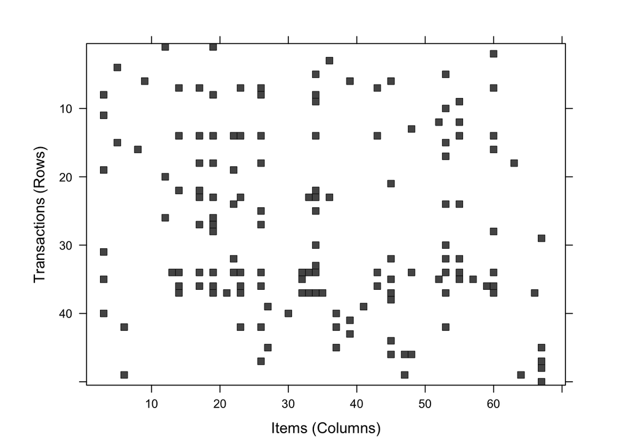

```r
#############
##### D #####
#############

image(Walmart_trans[1:50])
```

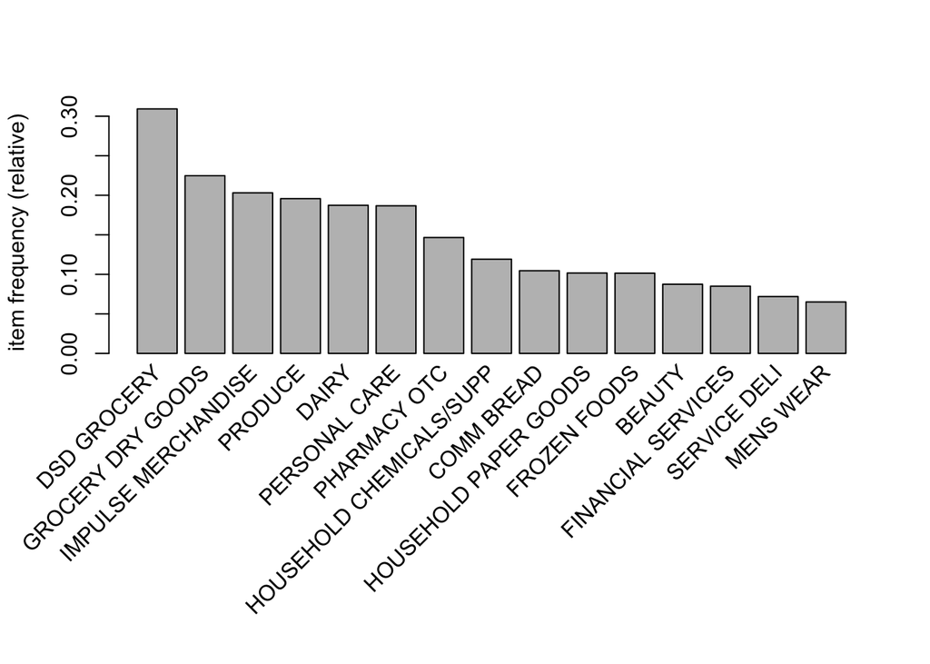

```r
#############
##### E #####
#############

itemFrequencyPlot(Walmart_trans, topN=15)
```

# Assoc-Rule Mining

Association rule mining (use Walmart_basket.csv)

A. Do the following steps. i. Use the “apriori” function to generate between 50 and 100 association rules from the input data (i.e., Walmart_trans). Set your own minimum support and confidence threshold levels to do so. ii. Show the model to check the number of association rules (it should be between 50 and 100) iii. Show the entire rules in descending order of their lift values using the “inspect” function. iv. Create a new variable containing a subset of rules that have “DAIRY” on the right-hand side. Show this subset of rules in descending order of their lift values using the “inspect” function.

B. Do the following steps. i. Use the “apriori” function to generate between 100 and 200 association rules from the input data (i.e., Walmart_trans). Set your own minimum support and confidence threshold levels to do so. ii. Show the model to check the number of association rules (it should be between 100 and 200) iii. Show the entire rules in descending order of their confidence values using the “inspect” function. iv. Create a new variable containing a subset of rules that have “PRODUCE” on the left-hand side. Show this subset of rules in descending order of their confidence values using the “inspect” function.

```r
#############
### A - i ###
#############

wal_64 <- apriori(Walmart_trans, parameter = list(support = 0.05, confidence = 0.25))
```

```
## Apriori
##
## Parameter specification:
##  confidence minval smax arem  aval originalSupport maxtime support minlen
##        0.25    0.1    1 none FALSE            TRUE       5    0.05      1
##  maxlen target   ext
##      10  rules FALSE
##
## Algorithmic control:
##  filter tree heap memopt load sort verbose
##     0.1 TRUE TRUE  FALSE TRUE    2    TRUE
##
## Absolute minimum support count: 4783
##
## set item appearances ...[0 item(s)] done [0.00s].
## set transactions ...[70 item(s), 95675 transaction(s)] done [0.02s].
## sorting and recoding items ... [20 item(s)] done [0.00s].
## creating transaction tree ... done [0.03s].
## checking subsets of size 1 2 3 4 done [0.01s].
## writing ... [64 rule(s)] done [0.00s].
## creating S4 object  ... done [0.02s].
```

```r
#############
### A - ii ##
#############

wal_64
```

```
## set of 64 rules
```

```r
#############
## A - iii ##
#############

inspect(sort(wal_64, by = 'lift'))
```

```
##      lhs                                        rhs
## [1]  {DAIRY,GROCERY DRY GOODS}               => {COMM BREAD}
## [2]  {DSD GROCERY,GROCERY DRY GOODS,PRODUCE} => {DAIRY}
## [3]  {COMM BREAD,GROCERY DRY GOODS}          => {DAIRY}
## [4]  {DSD GROCERY,GROCERY DRY GOODS}         => {COMM BREAD}
## [5]  {COMM BREAD,DAIRY}                      => {GROCERY DRY GOODS}
## [6]  {DAIRY,DSD GROCERY,PRODUCE}             => {GROCERY DRY GOODS}
## [7]  {GROCERY DRY GOODS,PRODUCE}             => {DAIRY}
## [8]  {COMM BREAD,DSD GROCERY}                => {GROCERY DRY GOODS}
## [9]  {DAIRY,DSD GROCERY,GROCERY DRY GOODS}   => {PRODUCE}
## [10] {DAIRY,PRODUCE}                         => {GROCERY DRY GOODS}
## [11] {DSD GROCERY,PRODUCE}                   => {DAIRY}
## [12] {DAIRY}                                 => {COMM BREAD}
## [13] {COMM BREAD}                            => {DAIRY}
## [14] {DSD GROCERY,GROCERY DRY GOODS}         => {DAIRY}
```

[output cut: 115 more lines]

```r
#############
### A - iv ##
#############

dairy_rules <- subset(wal_64, rhs %in% "DAIRY")
inspect(sort(dairy_rules, by='lift'))
```

```
##      lhs                                        rhs     support    confidence
## [1]  {DSD GROCERY,GROCERY DRY GOODS,PRODUCE} => {DAIRY} 0.05326365 0.7223246
## [2]  {COMM BREAD,GROCERY DRY GOODS}          => {DAIRY} 0.05118369 0.7095045
## [3]  {GROCERY DRY GOODS,PRODUCE}             => {DAIRY} 0.06963157 0.6562254
## [4]  {DSD GROCERY,PRODUCE}                   => {DAIRY} 0.06650640 0.6135377
## [5]  {COMM BREAD}                            => {DAIRY} 0.06339169 0.6061969
## [6]  {DSD GROCERY,GROCERY DRY GOODS}         => {DAIRY} 0.08176640 0.6021398
## [7]  {FROZEN FOODS}                          => {DAIRY} 0.06059054 0.5971979
## [8]  {GROCERY DRY GOODS}                     => {DAIRY} 0.11619545 0.5170217
## [9]  {PRODUCE}                               => {DAIRY} 0.09380716 0.4792546
## [10] {DSD GROCERY}                           => {DAIRY} 0.11658218 0.3769389
##      lift     count
## [1]  3.854990  5096
## [2]  3.786570  4897
## [3]  3.502224  6662
## [4]  3.274403  6363
## [5]  3.235226  6065
## [6]  3.213573  7823
## [7]  3.187199  5797
## [8]  2.759304 11117
## [9]  2.557744  8975
## [10] 2.011694 11154
```

```r
#############
### B - i ###
#############

wal_172 <- apriori(Walmart_trans, parameter = list(support = 0.035, confidence = 0.25))
```

```
## Apriori
##
## Parameter specification:
##  confidence minval smax arem  aval originalSupport maxtime support minlen
##        0.25    0.1    1 none FALSE            TRUE       5   0.035      1
##  maxlen target   ext
##      10  rules FALSE
##
## Algorithmic control:
##  filter tree heap memopt load sort verbose
##     0.1 TRUE TRUE  FALSE TRUE    2    TRUE
##
## Absolute minimum support count: 3348
##
## set item appearances ...[0 item(s)] done [0.00s].
## set transactions ...[70 item(s), 95675 transaction(s)] done [0.02s].
## sorting and recoding items ... [29 item(s)] done [0.00s].
## creating transaction tree ... done [0.03s].
## checking subsets of size 1 2 3 4 done [0.01s].
## writing ... [172 rule(s)] done [0.00s].
## creating S4 object  ... done [0.01s].
```

```r
#############
### B - ii ##
#############

wal_172
```

```
## set of 172 rules
```

```r
#############
## B - iii ##
#############

inspect(sort(wal_172, by='confidence'))
```

```
##       lhs                           rhs                           support confidence     lift count
## [1]   {COMM BREAD,
##        DAIRY,
##        DSD GROCERY}              => {GROCERY DRY GOODS}        0.04076300  0.8569545 3.813093  3900
## [2]   {COMM BREAD,
##        DAIRY,
##        PRODUCE}                  => {GROCERY DRY GOODS}        0.03592370  0.8558267 3.808075  3437
## [3]   {COMM BREAD,
##        DSD GROCERY,
##        PRODUCE}                  => {GROCERY DRY GOODS}        0.03622681  0.8468116 3.767961  3466
## [4]   {DAIRY,
##        DSD GROCERY,
##        FROZEN FOODS}             => {GROCERY DRY GOODS}        0.03733473  0.8138528 3.621308  3572
## [5]   {DAIRY,
##        FROZEN FOODS,
##        GROCERY DRY GOODS}        => {DSD GROCERY}              0.03733473  0.8081448 2.612931  3572
## [6]   {COMM BREAD,
##        DAIRY}                    => {GROCERY DRY GOODS}        0.05118369  0.8074196 3.592683  4897
## [7]   {DAIRY,
##        PRE PACKED DELI}          => {GROCERY DRY GOODS}        0.03738699  0.8040009 3.577471  3577
## [8]   {GROCERY DRY GOODS,
##        PRE PACKED DELI}          => {DAIRY}                    0.03738699  0.8038202 4.289926  3577
## [9]   {DAIRY,
##        DSD GROCERY,
##        PRODUCE}                  => {GROCERY DRY GOODS}        0.05326365  0.8008801 3.563585  5096
## [10]  {DSD GROCERY,
##        PRE PACKED DELI}          => {GROCERY DRY GOODS}        0.03698981  0.7992322 3.556252  3539
## [11]  {COMM BREAD,
##        PRODUCE}                  => {GROCERY DRY GOODS}        0.04563366  0.7971517 3.546995  4366
## [12]  {COMM BREAD,
##        DAIRY,
##        GROCERY DRY GOODS}        => {DSD GROCERY}              0.04076300  0.7964060 2.574977  3900
## [13]  {GROCERY DRY GOODS,
##        PRE PACKED DELI}          => {DSD GROCERY}              0.03698981  0.7952809 2.571339  3539
## [14]  {COMM BREAD,
##        GROCERY DRY GOODS,
##        PRODUCE}                  => {DSD GROCERY}              0.03622681  0.7938617 2.566751  3466
## [15]  {COMM BREAD,
##        GROCERY DRY GOODS,
##        PRODUCE}                  => {DAIRY}                    0.03592370  0.7872194 4.201329  3437
```

[output cut: 242 more lines]

```
## [159] {GROCERY DRY GOODS}        => {FROZEN FOODS}             0.06210609  0.2763464 2.723750  5942
## [160] {IMPULSE MERCHANDISE}      => {GROCERY DRY GOODS}        0.05535406  0.2724981 1.212504  5296
## [161] {DSD GROCERY,
##        GROCERY DRY GOODS}        => {PRE PACKED DELI}          0.03698981  0.2723984 4.321293  3539
## [162] {DSD GROCERY}              => {IMPULSE MERCHANDISE}      0.08383590  0.2710621 1.334390  8021
## [163] {PERSONAL CARE}            => {IMPULSE MERCHANDISE}      0.05029527  0.2693686 1.326053  4812
## [164] {GROCERY DRY GOODS}        => {PERSONAL CARE}            0.06052783  0.2693238 1.442429  5791
## [165] {PERSONAL CARE}            => {DAIRY}                    0.04913509  0.2631549 1.404437  4701
## [166] {DAIRY}                    => {PERSONAL CARE}            0.04913509  0.2622302 1.404437  4701
## [167] {PERSONAL CARE}            => {PRODUCE}                  0.04886334  0.2616995 1.337005  4675
## [168] {PHARMACY OTC}             => {PRODUCE}                  0.03786778  0.2583428 1.319856  3623
## [169] {DAIRY}                    => {HOUSEHOLD CHEMICALS/SUPP} 0.04830938  0.2578234 2.163604  4622
## [170] {GROCERY DRY GOODS}        => {HOUSEHOLD CHEMICALS/SUPP} 0.05774758  0.2569528 2.156299  5525
## [171] {PRODUCE}                  => {FROZEN FOODS}             0.05023256  0.2566348 2.529467  4806
## [172] {PHARMACY OTC}             => {IMPULSE MERCHANDISE}      0.03696891  0.2522105 1.241587  3537
```

```r
#############
### B - iv ##
#############

produce_rules <- subset(wal_172, lhs %in% "PRODUCE")
inspect(sort(produce_rules, by='confidence'))
```

```
##      lhs                                        rhs                 support
## [1]  {COMM BREAD,DAIRY,PRODUCE}              => {GROCERY DRY GOODS} 0.03592370
## [2]  {COMM BREAD,DSD GROCERY,PRODUCE}        => {GROCERY DRY GOODS} 0.03622681
## [3]  {DAIRY,DSD GROCERY,PRODUCE}             => {GROCERY DRY GOODS} 0.05326365
## [4]  {COMM BREAD,PRODUCE}                    => {GROCERY DRY GOODS} 0.04563366
## [5]  {COMM BREAD,GROCERY DRY GOODS,PRODUCE}  => {DSD GROCERY}       0.03622681
## [6]  {COMM BREAD,GROCERY DRY GOODS,PRODUCE}  => {DAIRY}             0.03592370
## [7]  {DAIRY,GROCERY DRY GOODS,PRODUCE}       => {DSD GROCERY}       0.05326365
## [8]  {FROZEN FOODS,PRODUCE}                  => {GROCERY DRY GOODS} 0.03826496
## [9]  {FROZEN FOODS,PRODUCE}                  => {DAIRY}             0.03817089
## [10] {FROZEN FOODS,PRODUCE}                  => {DSD GROCERY}       0.03760648
## [11] {COMM BREAD,PRODUCE}                    => {DSD GROCERY}       0.04278025
## [12] {DAIRY,PRODUCE}                         => {GROCERY DRY GOODS} 0.06963157
## [13] {COMM BREAD,PRODUCE}                    => {DAIRY}             0.04197544
## [14] {DSD GROCERY,GROCERY DRY GOODS,PRODUCE} => {DAIRY}             0.05326365
```

[output cut: 51 more lines]